# DecisionTree

### Background

Using devices such as Jawbone Up, Nike FuelBand, and Fitbit it is now possible to collect a large amount of data about personal activity relatively inexpensively. These type of devices are part of the quantified self movement – a group of enthusiasts who take measurements about themselves regularly to improve their health, to find patterns in their behavior, or because they are tech geeks. One thing that people regularly do is quantify how much of a particular activity they do, but they rarely quantify how well they do it. In this project, your goal will be to use data from accelerometers on the belt, forearm, arm, and dumbell of 6 participants. They were asked to perform barbell lifts correctly and incorrectly in 5 different ways. More information is available from the website here: http://groupware.les.inf.puc-rio.br/har (see the section on the Weight Lifting Exercise Dataset).

### Data

The training data for this project are available here:

https://d396qusza40orc.cloudfront.net/predmachlearn/pml-training.csv

The test data are available here:

https://d396qusza40orc.cloudfront.net/predmachlearn/pml-testing.csv

The data for this project come from this source: http://groupware.les.inf.puc-rio.br/har. If you use the document you create for this class for any purpose please cite them as they have been very generous in allowing their data to be used for this kind of assignment.

### Loading and processing the training and testing dataset

```r
library(caret)
library(randomForest)
set.seed(1111)
trainData <- read.table(".\\data\\pml-training.csv",sep=",",header = TRUE, na.strings=c("NA","#DIV/0!",""))
testData <- read.table(".\\data\\pml-testing.csv",sep=",",header = TRUE, na.strings=c("NA","#DIV/0!",""))

dim(trainData)
```

```
## [1] 19622   160
```

```r
dim(testData)
```

```
## [1]  20 160
```

```r
#Delete unused columns
trainData <- trainData[,-c(1:7)]
testData <- testData[,-c(1:7)]

#Delete columns with all missing values
trainData <- trainData[,colSums(is.na(trainData))==0]
testData <- testData[,colSums(is.na(testData))==0]
dim(trainData)
```

```
## [1] 19622    53
```

```r
dim(testData)
```

```
## [1] 20 53
```

```r
head(trainData)
```

```
##   roll_belt pitch_belt yaw_belt total_accel_belt gyros_belt_x gyros_belt_y
## 1      1.41       8.07    -94.4                3         0.00         0.00
## 2      1.41       8.07    -94.4                3         0.02         0.00
## 3      1.42       8.07    -94.4                3         0.00         0.00
## 4      1.48       8.05    -94.4                3         0.02         0.00
## 5      1.48       8.07    -94.4                3         0.02         0.02
## 6      1.45       8.06    -94.4                3         0.02         0.00
##   gyros_belt_z accel_belt_x accel_belt_y accel_belt_z magnet_belt_x
## 1        -0.02          -21            4           22            -3
## 2        -0.02          -22            4           22            -7
## 3        -0.02          -20            5           23            -2
## 4        -0.03          -22            3           21            -6
## 5        -0.02          -21            2           24            -6
## 6        -0.02          -21            4           21             0
##   magnet_belt_y magnet_belt_z roll_arm pitch_arm yaw_arm total_accel_arm
```

[output cut: 69 more lines]

```r
head(testData)
```

```
##   roll_belt pitch_belt yaw_belt total_accel_belt gyros_belt_x gyros_belt_y
## 1    123.00      27.00    -4.75               20        -0.50        -0.02
## 2      1.02       4.87   -88.90                4        -0.06        -0.02
## 3      0.87       1.82   -88.50                5         0.05         0.02
## 4    125.00     -41.60   162.00               17         0.11         0.11
## 5      1.35       3.33   -88.60                3         0.03         0.02
## 6     -5.92       1.59   -87.70                4         0.10         0.05
##   gyros_belt_z accel_belt_x accel_belt_y accel_belt_z magnet_belt_x
## 1        -0.46          -38           69         -179           -13
## 2        -0.07          -13           11           39            43
## 3         0.03            1           -1           49            29
## 4        -0.16           46           45         -156           169
## 5         0.00           -8            4           27            33
## 6        -0.13          -11          -16           38            31
##   magnet_belt_y magnet_belt_z roll_arm pitch_arm yaw_arm total_accel_arm
```

[output cut: 69 more lines]

### Partition traing dataset for cross validation

```r
inTrain <- createDataPartition(trainData$classe,p=0.75,list=FALSE)
training <- trainData[inTrain,]
testing <- trainData[-inTrain,]
```

### The frequency chart for training data

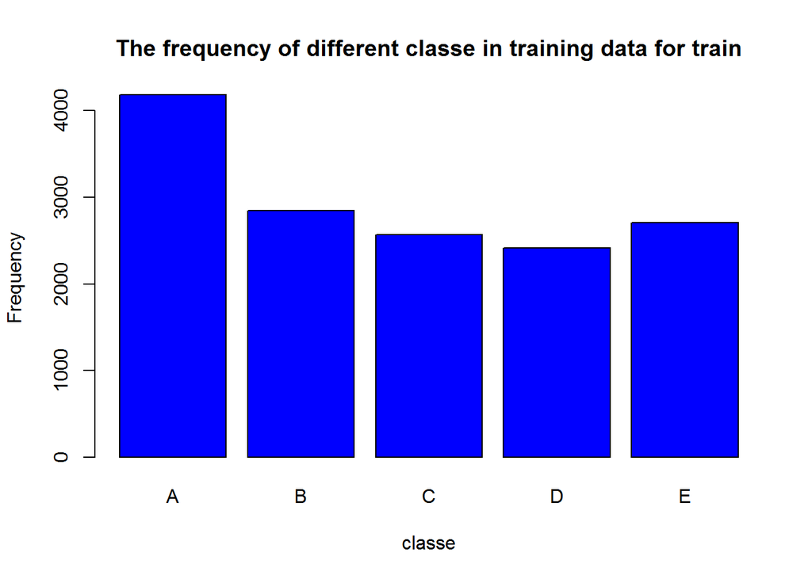

### Build model 1: Decision tree model

```r
modFit <- train(classe~.,method="rpart",data=training)

predict1 <- predict(modFit,newdata=testing)
confusionMatrix(predict1,testing$classe)
```

```
## Confusion Matrix and Statistics
##
##           Reference
## Prediction    A    B    C    D    E
##          A 1264  399  410  352  129
##          B   22  296   27  145  131
##          C  107  254  418  307  268
##          D    0    0    0    0    0
##          E    2    0    0    0  373
##
## Overall Statistics
##
##                Accuracy : 0.4794
##                  95% CI : (0.4653, 0.4935)
##     No Information Rate : 0.2845
##     P-Value [Acc > NIR] : < 2.2e-16
##
##                   Kappa : 0.3196
##  Mcnemar's Test P-Value : NA
##
## Statistics by Class:
##
##                      Class: A Class: B Class: C Class: D Class: E
## Sensitivity            0.9061  0.31191  0.48889   0.0000  0.41398
## Specificity            0.6324  0.91783  0.76883   1.0000  0.99950
## Pos Pred Value         0.4949  0.47665  0.30871      NaN  0.99467
## Neg Pred Value         0.9443  0.84754  0.87690   0.8361  0.88342
## Prevalence             0.2845  0.19352  0.17435   0.1639  0.18373
## Detection Rate         0.2577  0.06036  0.08524   0.0000  0.07606
## Detection Prevalence   0.5208  0.12663  0.27610   0.0000  0.07647
## Balanced Accuracy      0.7692  0.61487  0.62886   0.5000  0.70674
```

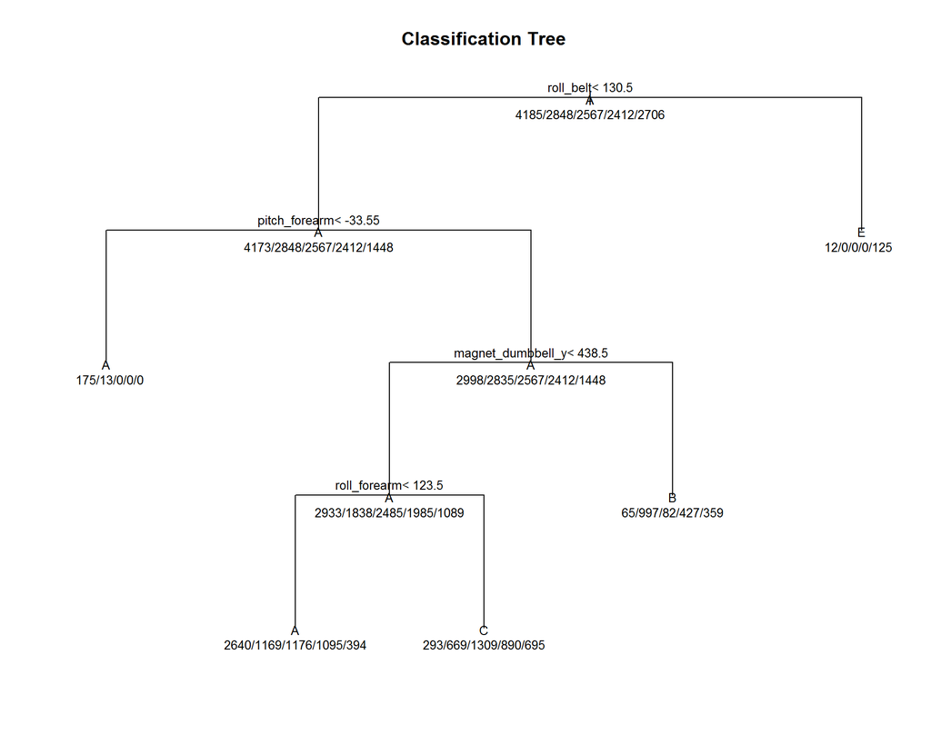

```r
plot(modFit$finalModel,uniform=TRUE,main="Classification Tree")
text(modFit$finalModel,use.n=TRUE,all=TRUE,cex=.8)
```

### Build model 2: Random forest model

```r
modFit2 <- randomForest(classe ~. , data=training, method="class")
predict2 <- predict(modFit2,newdata=testing)
confusionMatrix(predict2,testing$classe)
```

```
## Confusion Matrix and Statistics
##
##           Reference
## Prediction    A    B    C    D    E
##          A 1394    4    0    0    0
##          B    1  943    1    0    0
##          C    0    2  854   11    1
##          D    0    0    0  792    1
##          E    0    0    0    1  899
##
## Overall Statistics
##
##                Accuracy : 0.9955
##                  95% CI : (0.9932, 0.9972)
##     No Information Rate : 0.2845
##     P-Value [Acc > NIR] : < 2.2e-16
##
##                   Kappa : 0.9943
##  Mcnemar's Test P-Value : NA
##
## Statistics by Class:
##
##                      Class: A Class: B Class: C Class: D Class: E
## Sensitivity            0.9993   0.9937   0.9988   0.9851   0.9978
## Specificity            0.9989   0.9995   0.9965   0.9998   0.9998
## Pos Pred Value         0.9971   0.9979   0.9839   0.9987   0.9989
## Neg Pred Value         0.9997   0.9985   0.9998   0.9971   0.9995
## Prevalence             0.2845   0.1935   0.1743   0.1639   0.1837
## Detection Rate         0.2843   0.1923   0.1741   0.1615   0.1833
## Detection Prevalence   0.2851   0.1927   0.1770   0.1617   0.1835
## Balanced Accuracy      0.9991   0.9966   0.9977   0.9924   0.9988
```

### Expected out of sample error

The sample accuracy is equal to the correct classified observations over the total sample in the data. So, the out of sample error is equal to “1-accuracy” in the sample data.

### Compare accuracy between models

According to the confusionmatrix above the two model, the random forest has the better accuracy. So, we choose the “random forest” for our predicting model.